# Ch17Practice

Justine

2021/7/3

# Home

```r
library(lattice)
```

### 是非題

1.(O)我們可以用histogram()函數將數據導入，直接瞭解數據的分佈作推斷  
由於這個函數是在擴展包lattice內，所以使用前先以library(lattice)載入  
2.(X)histogram()函數已經在R的基本設定中，因此不需要下載任何擴充包，可以直接執行，不會有任何錯誤訊息  
3.(O)shapiro.test()函數已經在R的基本設定中，因此不需要下載任何擴充包，可以直接執行檢測，不會有任何錯誤訊息  
4.(O)我們想要了解數據框x中的數值變數y在不同的因子變數sex下分開檢驗其y數據，瞭解是否符合常態分配。我們已經下載了相關的擴充包後，可以使用以下指令來完成檢測  
> histogram(~y|sex,data=x)  
7.(X)我們使用了shapiro.test(x)函數對數值變數x進行檢測，結果x$p.value的數值為0.12，表示有強烈證據顯示x符合了常態分配

### 選擇題

1.(A)以下何種函數在使用前必須下載擴充包才能夠順利執行，不會產生錯誤訊息?  
(A)histogram() (B)shapiro.test()  
(C)qqnorm() (D)qqline()  
2.(A)我們想要了解數據框x中的數值變數y在不同的因子變數sex下分開檢驗其y數據，瞭解是否符合常態分配  
我們已經下載了相關的擴充包後，可以使用以下histogram()指令來正確完成檢測  
(A)> histogram(~y|sex,data=x)  
(B)> histogram(y|sex,data=x)  
(C)> histogram(x$y|sex) (D)> histogram(~y|sex) 5.(C)我們使用了shapiro.test(x)函數對數值變數x進行檢測 以下哪一個x$p.value數值結果，表示有強烈證據顯示拒絕了x符合常態分配?  
(A)0.12 (B)0.58 (C)0.001 (D)0.95  
6.(D)我們使用了shapiro.test()分別對nortest2$F與nortest2$M進行了檢測得到如下的結果:  
> nortest2$F$p.value  
[1] 0.5256088  
> nortest2$M$p.value  
[1] 0.0068288

```
以下的結論哪一個最正確？
(A)nortest2$F與nortest2$M均符合常態分配
(B)nortest2$F與nortest2$M均不符合常態分配
(C)nortest2$F不符合常態分配而nortest2$M符合常態分配
(D)nortest2$F符合常態分配而nortest2$M不符合常態分配
```

### 複選題

1.(ABC)以下何種函數可以將數據導入，不需要下載擴充包，直接瞭解數據的分佈作推斷?  
(A)hist() (B)qqnorm()  
(C)shapiro.test() (D)dotplot() (E)histogram()  
2.(ABC)以下何種函數可以用來檢測數值數據是否為常態分配?  
(A)histogram() (B)qqnorm()  
(C)shapiro.test() (D)boxplot() (E) dotchart()

### 實作題

1.使用histogram()函數繪製crabs數據框的FL變數的直方圖；並使用sex因子變數作為條件變數再繪製條狀直方圖

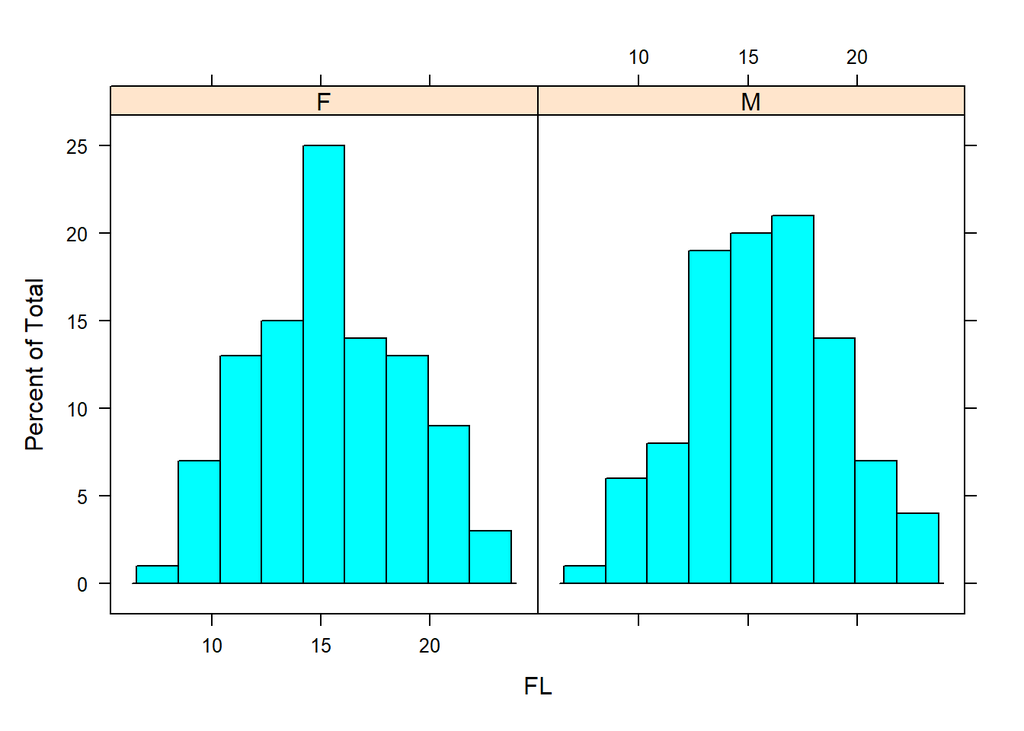

```r
#install.packages(MASS)
library(MASS)
histogram(~FL|sex,data = crabs)
```

2.使用qqnorm()與qqline()函數繪製crabs數據框的FL變數的QQ圖

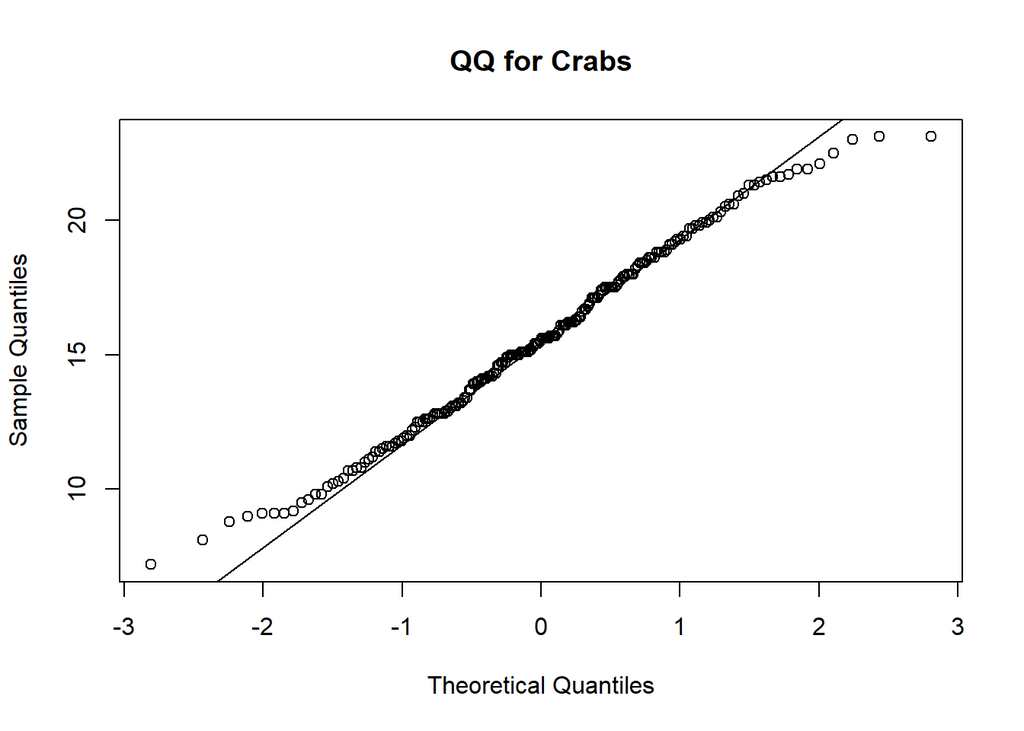

```r
qqnorm(crabs$FL,main = "QQ for Crabs")
qqline(crabs$FL)
```

再使用shapiro.test()檢測crabs$FL變數是否符合常態分配

```r
nortest <- shapiro.test(crabs$FL)
nortest$p.value
```

```
## [1] 0.2022775
```